# 18. Bivariate_Analysis_and_Pandas_Profiling

Bivariate Analysis

Through bivariate analysis we try to analyze two variables simultaneously. As opposed to univariate analysis where we check the characteristics of a single variable, in bivariate analysis we try to determine if there is any relationship between two variables.

There are essentially 3 major scenarios that we will come accross when we perform bivariate analysis

1. Both variables of interest are qualitative
2. One variable is qualitative and the other is quantitative
3. Both variables are quantitative

For the purpose of this exercise, we will explore few most popular techniques to perform bivariate analysis.

The following plots are not limited to the headings they are under. They are the options we have if we face a certain scenario.

### Numerical vs. Numerical

```
1. Scatterplot
2. Line plot
3. Heatmap for correlation
4. Joint plot
```

### Categorical vs. Numerical

```
1. Bar chart
2. Voilin plot
3. Categorical box plot
4.Swarm plot
```

## Two Categorical Variables

```
1. Bar chart
2. Grouped bar chart
3. Point plot
```

Case Study (Suicide Rates Overview 1985 to 2016)

1.1 Loading the libraries

```python
import numpy as np
import pandas as pd
import matplotlib.pyplot as plt
import seaborn as sns
```

1.2 import the dataset

```python
data=pd.read_csv('master.csv')
```

1.3 check the data head()

```python
data.head()
```

|  | country | year | sex | age | suicides_no | population | suicides/100k pop | country-year | HDI for year | gdp_for_year ($) | gdp_per_capita ($) | generation |
| --- | --- | --- | --- | --- | --- | --- | --- | --- | --- | --- | --- | --- |
| 0 | Albania | 1987 | male | 15-24 years | 21 | 312900 | 6.71 | Albania1987 | NaN | 2,156,624,900 | 796 | Generation X |
| 1 | Albania | 1987 | male | 35-54 years | 16 | 308000 | 5.19 | Albania1987 | NaN | 2,156,624,900 | 796 | Silent |
| 2 | Albania | 1987 | female | 15-24 years | 14 | 289700 | 4.83 | Albania1987 | NaN | 2,156,624,900 | 796 | Generation X |
| 3 | Albania | 1987 | male | 75+ years | 1 | 21800 | 4.59 | Albania1987 | NaN | 2,156,624,900 | 796 | G.I. Generation |
| 4 | Albania | 1987 | male | 25-34 years | 9 | 274300 | 3.28 | Albania1987 | NaN | 2,156,624,900 | 796 | Boomers |

1.4 Check the data.describe()

```python
data.describe()
```

|  | year | suicides_no | population | suicides/100k pop | HDI for year | gdp_per_capita ($) |
| --- | --- | --- | --- | --- | --- | --- |
| count | 27820.000000 | 27820.000000 | 2.782000e+04 | 27820.000000 | 8364.000000 | 27820.000000 |
| mean | 2001.258375 | 242.574407 | 1.844794e+06 | 12.816097 | 0.776601 | 16866.464414 |
| std | 8.469055 | 902.047917 | 3.911779e+06 | 18.961511 | 0.093367 | 18887.576472 |
| min | 1985.000000 | 0.000000 | 2.780000e+02 | 0.000000 | 0.483000 | 251.000000 |
| 25% | 1995.000000 | 3.000000 | 9.749850e+04 | 0.920000 | 0.713000 | 3447.000000 |
| 50% | 2002.000000 | 25.000000 | 4.301500e+05 | 5.990000 | 0.779000 | 9372.000000 |
| 75% | 2008.000000 | 131.000000 | 1.486143e+06 | 16.620000 | 0.855000 | 24874.000000 |
| max | 2016.000000 | 22338.000000 | 4.380521e+07 | 224.970000 | 0.944000 | 126352.000000 |

1.5 Check the columns

```python
data.columns
```

```
Index(['country', 'year', 'sex', 'age', 'suicides_no', 'population',
       'suicides/100k pop', 'country-year', 'HDI for year',
       ' gdp_for_year ($) ', 'gdp_per_capita ($)', 'generation'],
      dtype='object')
```

1.6 Checking the shape of data

```python
data.shape
```

```
(27820, 12)
```

1.7 Count the datatypes

```python
data.dtypes.value_counts()
```

```
object     6
int64      4
float64    2
dtype: int64
```

1.8 Check the data set information

```python
data.info()
```

```
<class 'pandas.core.frame.DataFrame'>
RangeIndex: 27820 entries, 0 to 27819
Data columns (total 12 columns):
country               27820 non-null object
year                  27820 non-null int64
sex                   27820 non-null object
age                   27820 non-null object
suicides_no           27820 non-null int64
population            27820 non-null int64
suicides/100k pop     27820 non-null float64
country-year          27820 non-null object
HDI for year          8364 non-null float64
 gdp_for_year ($)     27820 non-null object
gdp_per_capita ($)    27820 non-null int64
generation            27820 non-null object
dtypes: float64(2), int64(4), object(6)
memory usage: 2.5+ MB
```

1.9 Checking the dataset missing values

```python
def missing_check(df):
    total = df.isnull().sum().sort_values(ascending=False)   # total number of null values
    percent = (df.isnull().sum()/df.isnull().count()).sort_values(ascending=False)  # percentage of values that are null
    missing_data = pd.concat([total, percent], axis=1, keys=['Total', 'Percent'])  # putting the above two together
    return missing_data # return the dataframe
missing_check(data)
```

|  | Total | Percent |
| --- | --- | --- |
| HDI for year | 19456 | 0.699353 |
| generation | 0 | 0.000000 |
| gdp_per_capita ($) | 0 | 0.000000 |
| gdp_for_year ($) | 0 | 0.000000 |
| country-year | 0 | 0.000000 |
| suicides/100k pop | 0 | 0.000000 |
| population | 0 | 0.000000 |
| suicides_no | 0 | 0.000000 |
| age | 0 | 0.000000 |
| sex | 0 | 0.000000 |
| year | 0 | 0.000000 |
| country | 0 | 0.000000 |

```python
data[['suicides_no','population','suicides/100k pop','gdp_per_capita ($)']].describe() #descriptive stats of continuous columns
```

|  | suicides_no | population | suicides/100k pop | gdp_per_capita ($) |
| --- | --- | --- | --- | --- |
| count | 27820.000000 | 2.782000e+04 | 27820.000000 | 27820.000000 |
| mean | 242.574407 | 1.844794e+06 | 12.816097 | 16866.464414 |
| std | 902.047917 | 3.911779e+06 | 18.961511 | 18887.576472 |
| min | 0.000000 | 2.780000e+02 | 0.000000 | 251.000000 |
| 25% | 3.000000 | 9.749850e+04 | 0.920000 | 3447.000000 |
| 50% | 25.000000 | 4.301500e+05 | 5.990000 | 9372.000000 |
| 75% | 131.000000 | 1.486143e+06 | 16.620000 | 24874.000000 |
| max | 22338.000000 | 4.380521e+07 | 224.970000 | 126352.000000 |

1.10 Frequency table for Age

One-Way Tables

```python
my_tab = pd.crosstab(index=data["age"],  # Make a crosstab
                     columns="count")                  # Name the count column
my_tab
```

| col_0 age | count |
| --- | --- |
| 15-24 years | 4642 |
| 25-34 years | 4642 |
| 35-54 years | 4642 |
| 5-14 years | 4610 |
| 55-74 years | 4642 |
| 75+ years | 4642 |

1.11 Bar plot to check Number of Suicides by top Countries

# This is an example of Numerical vs Categorical.

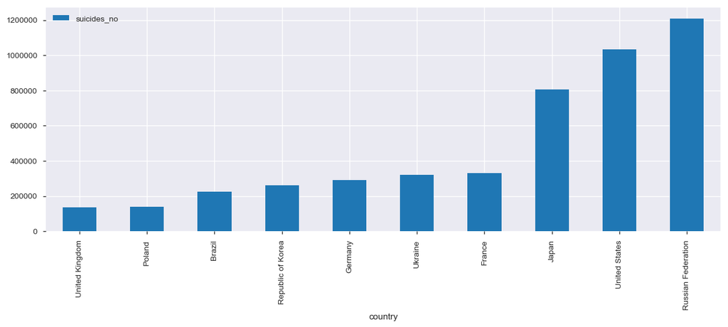

```python
data.groupby(by=['country'])['suicides_no'].sum().reset_index().sort_values(['suicides_no']).tail(10).plot(x='country',
                                                                                                           y='suicides_no',
                                                                                                           kind='bar',
                                                                                                           figsize=(15,5))
plt.show()
```

- Russia has the highest number of suicides followed by the US and Japan
- Russia, the US and Japan have exceptionally high counts of suicides compared to the others in the lot

1.12 Bar plot to check Number of Suicides by bottom Countries

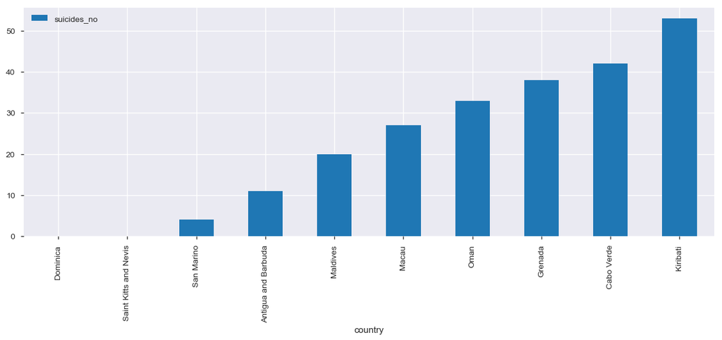

```python
data.groupby(by=['country'])['suicides_no'].sum().reset_index().sort_values(['suicides_no'],
                    ascending=True).head(10).plot(x='country',y='suicides_no',kind='bar', figsize=(15,5))

plt.show()
```

1.13 Bar plot for Number of Suicides Vs Age

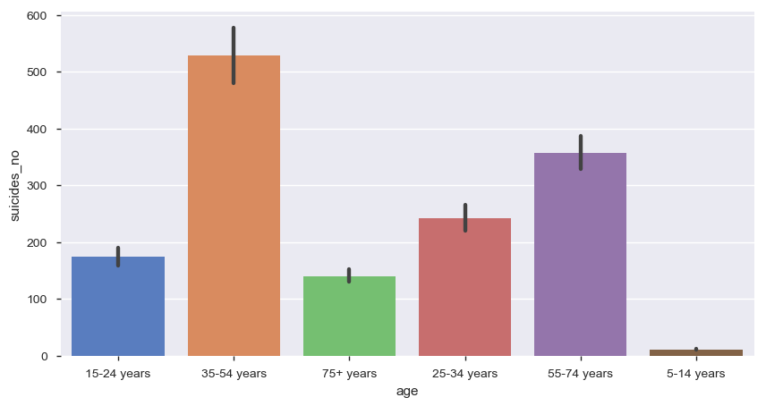

```python
plt.figure(figsize=(10,5))  # setting the figure size
ax = sns.barplot(x='age', y='suicides_no', data=data, palette='muted')  # barplot
```

1.14 Bar plot Number of Suicides Vs Sex

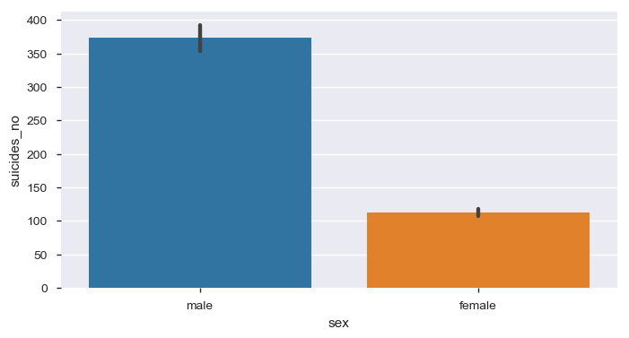

```python
plt.figure(figsize=(8,4))
ax = sns.barplot(x="sex", y="suicides_no", data=data)
```

1.15 Bar plot Number of Suicides Vs generation

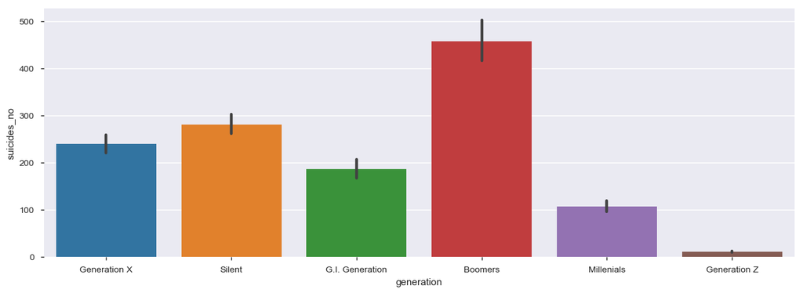

```python
plt.figure(figsize=(15,5))

ax = sns.barplot(x='generation', y='suicides_no', data=data)
```

- Suicides are the highest among the Boomers and lowest among Generation Z

1.15 Scatter plot Number of Suicides Vs population

# This is an examples of Numerical vs. Numerical

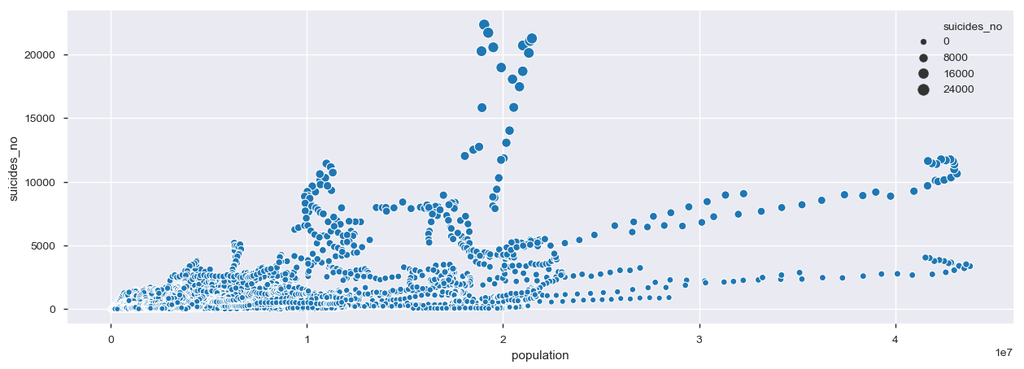

```python
figure = plt.figure(figsize=(15,5))

ax = sns.scatterplot(x=data['population'],y='suicides_no', data=data, size = "suicides_no") # scatter plot
```

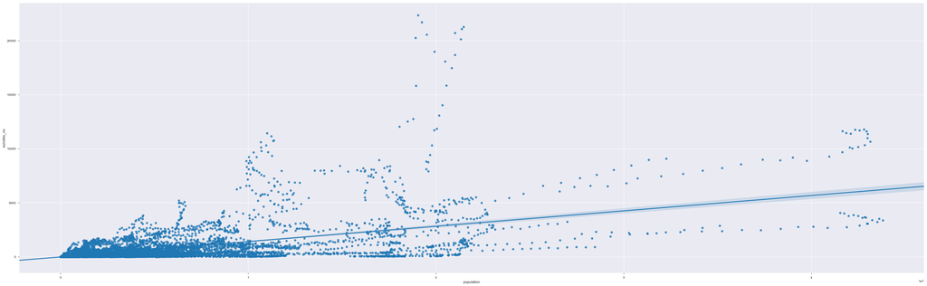

```python
figure = plt.figure(figsize=(50,15))

ax = sns.regplot(x='population',y='suicides_no', data=data ) # regression plot - scatter plot with a regression line
```

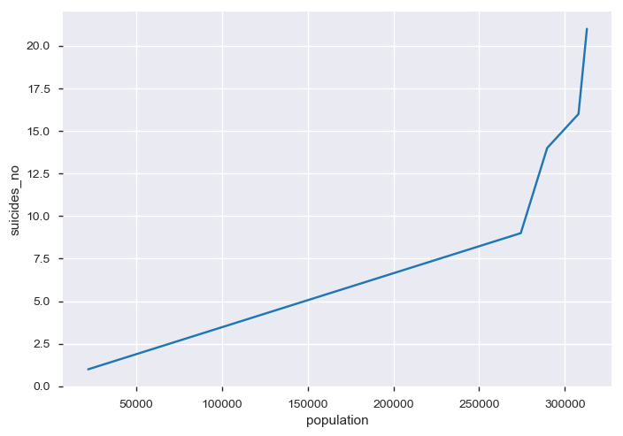

```python
#Here we plotting a line plot.
sns.lineplot(x='population',y='suicides_no', data=data.head() )
```

Scatter plot Number of Suicides/100kPopulation Vs GDP Per Capita

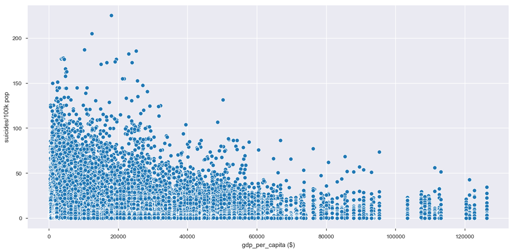

```python
figure = plt.figure(figsize=(15,7))

sns.scatterplot(x='gdp_per_capita ($)', y='suicides/100k pop', data=data) # scatter plot
plt.show()
```

Correlation among pairs of continuous variables

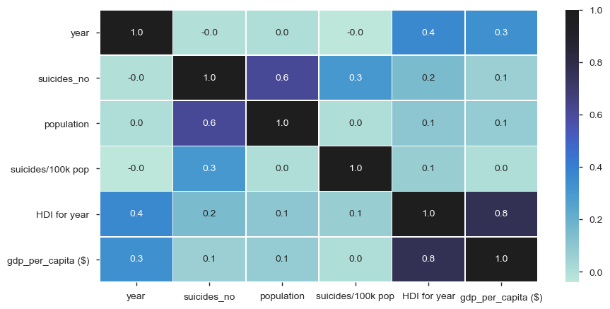

```python
plt.figure(figsize=(10,5))
sns.heatmap(data.corr(), annot=True, linewidths=.5, fmt= '.1f', center = 1 )  # heatmap
plt.show()
```

1.17.1 Bar plot To check Number of suicides by sex and age (three variables used to generate a single plot)

# This is an example of Numerical and 2 Categorical variables.

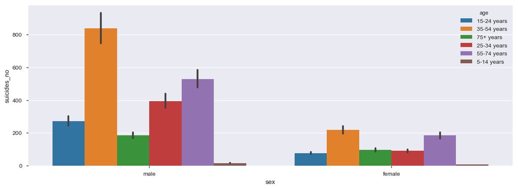

```python
plt.figure(figsize=(15,5))
sns.barplot(data=data,x='sex',y='suicides_no',hue='age')
plt.show()
```

1.17.2 Bar plot To check Number of suicides by sex and Generation(three variables used to generate a single plot)

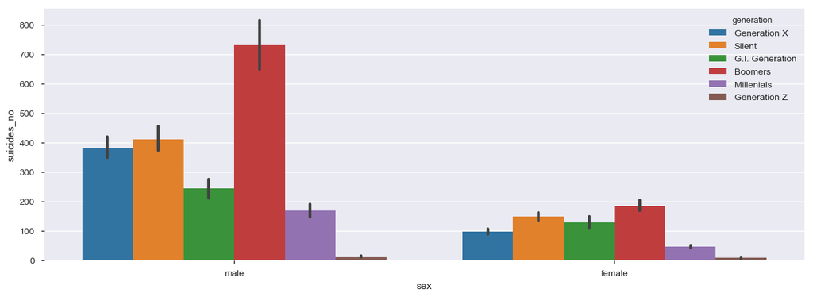

```python
plt.figure(figsize=(15,5))
sns.barplot(data=data,x='sex',y='suicides_no',hue='generation')
plt.show()
```

- Suicides in males apart from being higher, has a slight variation in distribution accross generations compared to the suicides of females accross generation
- In case of males, Generation X has higher suicide numbers compared to G.I Generation but incase of females, it is the opposite

1.18 Checking the No.of suicides: Country Vs Sex

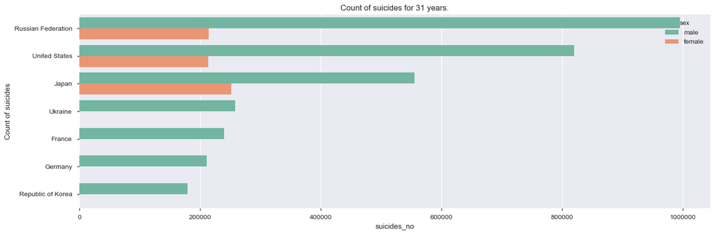

```python
suic_sum_m = data['suicides_no'].groupby([data['country'],data['sex']]).sum()  # number of suicides by country and sex
suic_sum_m = suic_sum_m.reset_index().sort_index(by='suicides_no',ascending=False) # sort in descending order
most_cont_m = suic_sum_m.head(10)  # getting the top ten countries in terms of suicides

fig = plt.figure(figsize=(15,5))
plt.title('Count of suicides for 31 years.')

sns.barplot(y='country',x='suicides_no',hue='sex',data=most_cont_m,palette='Set2');

plt.ylabel('Count of suicides')
plt.tight_layout()
```

- Japan has a higher proportion of female suicides compared to the countries with overall suicide rates even more high

Average number of suicides accross each generation for a given gender along with the confidence intevals - Point Plot

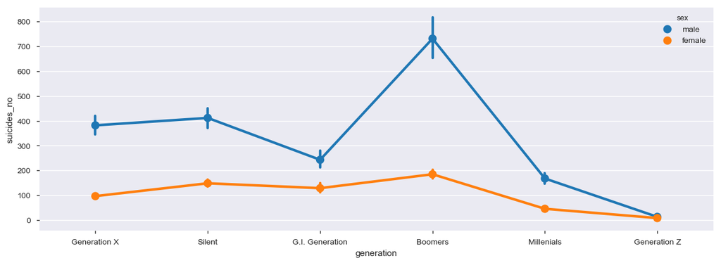

```python
plt.figure(figsize=(15,5))

sns.pointplot(x="generation", y="suicides_no", hue = 'sex',  data=data)
plt.show()
```

- The graph tells us the average suicides along with the confidence intervals
- Suicides among females in general don't seem to be fluctuating a lot
- Average suicides of Gen-Z are almost equally distributed accross genders

Distribution of population accross each generation - Violin plot

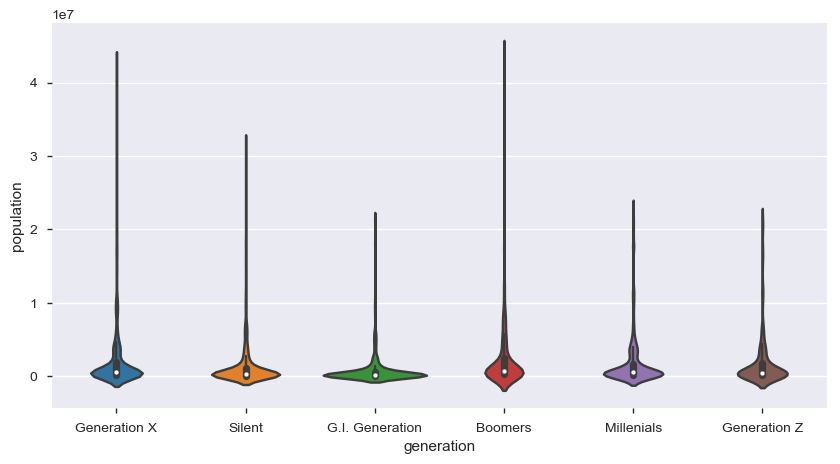

```python
plt.figure(figsize=(10,5))
sns.violinplot(x=data.generation, y=data['population'])
plt.show()
```

- The plot is similar to a box plot but here, we get a density function
- Distribution of population accross every eneration is highly skewed
- Potential of lot of outliers
- Try it yourself - Go ahead and check if there really are a lot of outliers in populations accross each generation Hint: use a boxplot

# Checking trends with Temporal Data

Temporal data is simply data that represents a state in time, such as the land-use patterns of Hong Kong in 1990, or total rainfall in Honolulu on July 1, 2009. Temporal data is collected to analyze weather patterns and other environmental variables, monitor traffic conditions, study demographic trends, and so on. This data comes from many sources ranging from manual data entry to data collected using observational sensors or generated from simulation models.

Checking pattern using Trend plot (1985-2015) suides Rate Vs Years

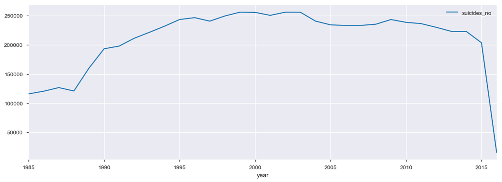

```python
data[['year','suicides_no']].groupby(['year']).sum().plot(figsize=(15,5))

plt.show()
```

Checking pattern using Trend plot (1985-2015) Population Vs Years

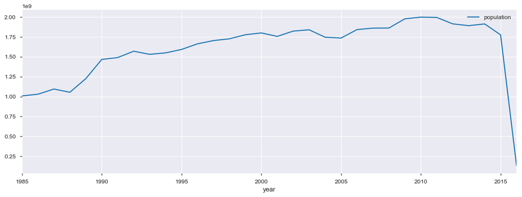

```python
data[['year','population']].groupby(['year']).sum().plot(figsize=(15,5))

plt.show()
```

Checking pattern using Trend plot (1985-2015) suicides/100k pop Vs Years

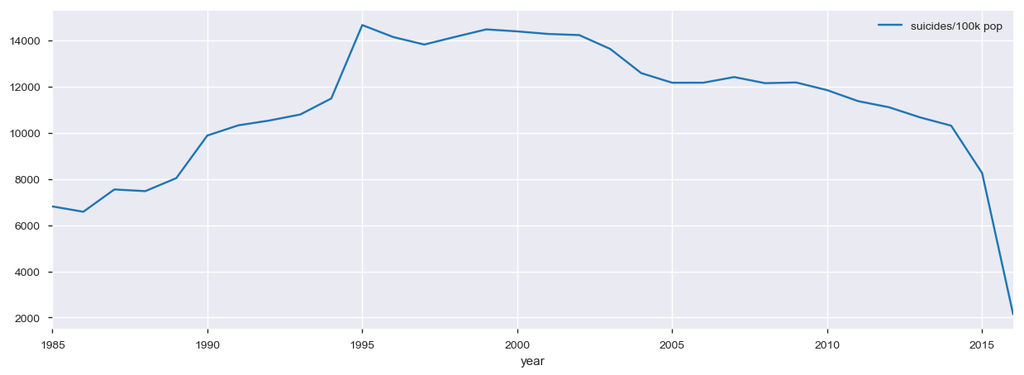

```python
data[['year','suicides/100k pop']].groupby(['year']).sum().plot(figsize=(15,5))

plt.show()
```

# Pandas Profiling with IPL data

Generates profile reports from a pandas DataFrame. pandas_profiling extends the pandas DataFrame with df.profile_report() for quick data analysis.

Link - https://pypi.org/project/pandas-profiling/

```python
#Installation step
#!pip install pandas-profiling
#or
import sys
!{sys.executable} -m pip install pandas-profiling
```

```
You are using pip version 18.1, however version 19.2.2 is available.
```

```python
!pip install -U pandas-profiling
```

[output not shown]

[output not shown]

```python
#import pandas_profiling
import pandas_profiling
```

The data is of IPL 2019 https://www.kaggle.com/divjain/ipl_data_till_2019/downloads/ipl_data_till_2019.zip/4#match_data.csv

```python
df = pd.read_csv('match_data.csv')
```

It has many useful functionalities but the best one is to generate an EDA report as given below.

Overview

Dataset info

| Number of variables | 24 |
| --- | --- |
| Number of observations | 746 |
| Total Missing (%) | 20.9% |
| Total size in memory | 140.0 KiB |
| Average record size in memory | 192.2 B |

Variables types

| Numeric | 5 |
| --- | --- |
| Categorical | 17 |
| Boolean | 0 |
| Date | 0 |
| Text (Unique) | 0 |
| Rejected | 2 |
| Unsupported | 0 |

Warnings

- `season` is highly correlated with `id` (ρ = 0.98562) Rejected

- `city` has 13 / 1.7% missing values Missing

- `date` has a high cardinality: 538 distinct values Warning

- `winner` has 12 / 1.6% missing values Missing

- `eliminator` has 738 / 98.9% missing values Missing

- `dl_applied` has 727 / 97.5% missing values Missing

- `win_by_runs` has 410 / 55.0% missing values Missing

- `win_by_wickets` has 348 / 46.6% missing values Missing

- `result` has 734 / 98.4% missing values Missing

- `overs` has constant value 20 Rejected

- `player_of_match` has a high cardinality: 224 distinct values Warning

- `umpire3` has 744 / 99.7% missing values Missing

Variables

id  
Numeric

| Distinct count | 746 |
| --- | --- |
| Unique (%) | 100.0% |
| Missing (%) | 0.0% |
| Missing (n) | 0 |
| Infinite (%) | 0.0% |
| Infinite (n) | 0 |

| Mean | 713550 |
| --- | --- |
| Minimum | 335982 |
| Maximum | 1178425 |
| Zeros (%) | 0.0% |

Toggle details

**Statistics**

Quantile statistics

| Minimum | 335982 |
| --- | --- |
| 5-th percentile | 336020 |
| Q1 | 501210 |
| Median | 598050 |
| Q3 | 980980 |
| 95-th percentile | 1175400 |
| Maximum | 1178425 |
| Range | 842443 |
| Interquartile range | 479780 |

Descriptive statistics

| Standard deviation | 284540 |
| --- | --- |
| Coef of variation | 0.39877 |
| Kurtosis | -1.3397 |
| Mean | 713550 |
| MAD | 253040 |
| Skewness | 0.35314 |
| Sum | 532309792 |
| Variance | 80964000000 |
| Memory size | 6.0 KiB |

**Histogram**

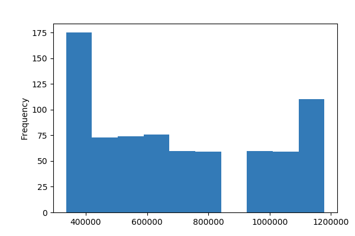

**Common Values**

| Value | Count | Frequency (%) |  |
| --- | --- | --- | --- |
| 392191 | 1 | 0.1% |  |
| 419108 | 1 | 0.1% |  |
| 829741 | 1 | 0.1% |  |
| 419116 | 1 | 0.1% |  |
| 419115 | 1 | 0.1% |  |
| 419114 | 1 | 0.1% |  |
| 829737 | 1 | 0.1% |  |
| 419112 | 1 | 0.1% |  |
| 829735 | 1 | 0.1% |  |
| 419110 | 1 | 0.1% |  |
| Other values (736) | 736 | 98.7% |  |

**Extreme Values**

Minimum 5 values

| Value | Count | Frequency (%) |  |
| --- | --- | --- | --- |
| 335982 | 1 | 0.1% |  |
| 335983 | 1 | 0.1% |  |
| 335984 | 1 | 0.1% |  |
| 335985 | 1 | 0.1% |  |
| 335986 | 1 | 0.1% |  |

Maximum 5 values

| Value | Count | Frequency (%) |  |
| --- | --- | --- | --- |
| 1178421 | 1 | 0.1% |  |
| 1178422 | 1 | 0.1% |  |
| 1178423 | 1 | 0.1% |  |
| 1178424 | 1 | 0.1% |  |
| 1178425 | 1 | 0.1% |  |

season  
Highly correlated

*This variable is highly correlated with `id` and should be ignored for analysis*

| Correlation | 0.98562 |
| --- | --- |

city  
Categorical

| Distinct count | 31 |
| --- | --- |
| Unique (%) | 4.2% |
| Missing (%) | 1.7% |
| Missing (n) | 13 |

| Mumbai | 99 |
| --- | --- |
| Kolkata | 77 |
| Delhi | 73 |
| Other values (27) | 484 |

Toggle details

| Value | Count | Frequency (%) |  |
| --- | --- | --- | --- |
| Mumbai | 99 | 13.3% |  |
| Kolkata | 77 | 10.3% |  |
| Delhi | 73 | 9.8% |  |
| Bangalore | 66 | 8.8% |  |
| Hyderabad | 63 | 8.4% |  |
| Chennai | 56 | 7.5% |  |
| Chandigarh | 54 | 7.2% |  |
| Jaipur | 47 | 6.3% |  |
| Pune | 38 | 5.1% |  |
| Durban | 15 | 2.0% |  |
| Other values (20) | 145 | 19.4% |  |

date  
Categorical

| Distinct count | 538 |
| --- | --- |
| Unique (%) | 72.1% |
| Missing (%) | 0.0% |
| Missing (n) | 0 |

| 2014-04-26 | 2 |
| --- | --- |
| 2011-05-08 | 2 |
| 2011-04-30 | 2 |
| Other values (535) | 740 |

Toggle details

| Value | Count | Frequency (%) |  |
| --- | --- | --- | --- |
| 2014-04-26 | 2 | 0.3% |  |
| 2011-05-08 | 2 | 0.3% |  |
| 2011-04-30 | 2 | 0.3% |  |
| 2012-04-08 | 2 | 0.3% |  |
| 2012-04-21 | 2 | 0.3% |  |
| 2010-04-10 | 2 | 0.3% |  |
| 2013-04-28 | 2 | 0.3% |  |
| 2017-05-01 | 2 | 0.3% |  |
| 2013-04-29 | 2 | 0.3% |  |
| 2008-04-20 | 2 | 0.3% |  |
| Other values (528) | 726 | 97.3% |  |

team1  
Categorical

| Distinct count | 15 |
| --- | --- |
| Unique (%) | 2.0% |
| Missing (%) | 0.0% |
| Missing (n) | 0 |

| Royal Challengers Bangalore | 97 |
| --- | --- |
| Chennai Super Kings | 89 |
| Kolkata Knight Riders | 85 |
| Other values (12) | 475 |

Toggle details

| Value | Count | Frequency (%) |  |
| --- | --- | --- | --- |
| Royal Challengers Bangalore | 97 | 13.0% |  |
| Chennai Super Kings | 89 | 11.9% |  |
| Kolkata Knight Riders | 85 | 11.4% |  |
| Kings XI Punjab | 84 | 11.3% |  |
| Mumbai Indians | 84 | 11.3% |  |
| Delhi Daredevils | 83 | 11.1% |  |
| Rajasthan Royals | 66 | 8.8% |  |
| Sunrisers Hyderabad | 53 | 7.1% |  |
| Deccan Chargers | 39 | 5.2% |  |
| Pune Warriors | 23 | 3.1% |  |
| Other values (5) | 43 | 5.8% |  |

team2  
Categorical

| Distinct count | 15 |
| --- | --- |
| Unique (%) | 2.0% |
| Missing (%) | 0.0% |
| Missing (n) | 0 |

| Mumbai Indians | 99 |
| --- | --- |
| Kolkata Knight Riders | 91 |
| Kings XI Punjab | 90 |
| Other values (12) | 466 |

Toggle details

| Value | Count | Frequency (%) |  |
| --- | --- | --- | --- |
| Mumbai Indians | 99 | 13.3% |  |
| Kolkata Knight Riders | 91 | 12.2% |  |
| Kings XI Punjab | 90 | 12.1% |  |
| Royal Challengers Bangalore | 82 | 11.0% |  |
| Rajasthan Royals | 80 | 10.7% |  |
| Delhi Daredevils | 78 | 10.5% |  |
| Chennai Super Kings | 71 | 9.5% |  |
| Sunrisers Hyderabad | 52 | 7.0% |  |
| Deccan Chargers | 36 | 4.8% |  |
| Pune Warriors | 23 | 3.1% |  |
| Other values (5) | 44 | 5.9% |  |

toss_winner  
Categorical

| Distinct count | 15 |
| --- | --- |
| Unique (%) | 2.0% |
| Missing (%) | 0.0% |
| Missing (n) | 0 |

| Mumbai Indians | 95 |
| --- | --- |
| Kolkata Knight Riders | 91 |
| Chennai Super Kings | 87 |
| Other values (12) | 473 |

Toggle details

| Value | Count | Frequency (%) |  |
| --- | --- | --- | --- |
| Mumbai Indians | 95 | 12.7% |  |
| Kolkata Knight Riders | 91 | 12.2% |  |
| Chennai Super Kings | 87 | 11.7% |  |
| Kings XI Punjab | 80 | 10.7% |  |
| Royal Challengers Bangalore | 80 | 10.7% |  |
| Delhi Daredevils | 80 | 10.7% |  |
| Rajasthan Royals | 79 | 10.6% |  |
| Sunrisers Hyderabad | 46 | 6.2% |  |
| Deccan Chargers | 43 | 5.8% |  |
| Pune Warriors | 20 | 2.7% |  |
| Other values (5) | 45 | 6.0% |  |

toss_decision  
Categorical

| Distinct count | 2 |
| --- | --- |
| Unique (%) | 0.3% |
| Missing (%) | 0.0% |
| Missing (n) | 0 |

| field | 457 |
| --- | --- |
| bat | 289 |

Toggle details

| Value | Count | Frequency (%) |  |
| --- | --- | --- | --- |
| field | 457 | 61.3% |  |
| bat | 289 | 38.7% |  |

winner  
Categorical

| Distinct count | 16 |
| --- | --- |
| Unique (%) | 2.1% |
| Missing (%) | 1.6% |
| Missing (n) | 12 |

| Mumbai Indians | 104 |
| --- | --- |
| Chennai Super Kings | 99 |
| Kolkata Knight Riders | 91 |
| Other values (12) | 440 |

Toggle details

| Value | Count | Frequency (%) |  |
| --- | --- | --- | --- |
| Mumbai Indians | 104 | 13.9% |  |
| Chennai Super Kings | 99 | 13.3% |  |
| Kolkata Knight Riders | 91 | 12.2% |  |
| Royal Challengers Bangalore | 82 | 11.0% |  |
| Kings XI Punjab | 79 | 10.6% |  |
| Rajasthan Royals | 73 | 9.8% |  |
| Delhi Daredevils | 67 | 9.0% |  |
| Sunrisers Hyderabad | 57 | 7.6% |  |
| Deccan Chargers | 29 | 3.9% |  |
| Gujarat Lions | 13 | 1.7% |  |
| Other values (5) | 40 | 5.4% |  |

eliminator  
Categorical

| Distinct count | 7 |
| --- | --- |
| Unique (%) | 0.9% |
| Missing (%) | 98.9% |
| Missing (n) | 738 |

| Kings XI Punjab | 2 |
| --- | --- |
| Rajasthan Royals | 2 |
| Sunrisers Hyderabad | 1 |
| Other values (3) | 3 |
| (Missing) | 738 |

Toggle details

| Value | Count | Frequency (%) |  |
| --- | --- | --- | --- |
| Kings XI Punjab | 2 | 0.3% |  |
| Rajasthan Royals | 2 | 0.3% |  |
| Sunrisers Hyderabad | 1 | 0.1% |  |
| Royal Challengers Bangalore | 1 | 0.1% |  |
| Delhi Capitals | 1 | 0.1% |  |
| Mumbai Indians | 1 | 0.1% |  |
| (Missing) | 738 | 98.9% |  |

dl_applied  
Categorical

| Distinct count | 2 |
| --- | --- |
| Unique (%) | 0.3% |
| Missing (%) | 97.5% |
| Missing (n) | 727 |

| D/L | 19 |
| --- | --- |
| (Missing) | 727 |

Toggle details

| Value | Count | Frequency (%) |  |
| --- | --- | --- | --- |
| D/L | 19 | 2.5% |  |
| (Missing) | 727 | 97.5% |  |

win_by_runs  
Numeric

| Distinct count | 89 |
| --- | --- |
| Unique (%) | 11.9% |
| Missing (%) | 55.0% |
| Missing (n) | 410 |
| Infinite (%) | 0.0% |
| Infinite (n) | 0 |

| Mean | 29.884 |
| --- | --- |
| Minimum | 1 |
| Maximum | 146 |
| Zeros (%) | 0.0% |

Toggle details

**Statistics**

Quantile statistics

| Minimum | 1 |
| --- | --- |
| 5-th percentile | 3 |
| Q1 | 11 |
| Median | 22 |
| Q3 | 39 |
| 95-th percentile | 86 |
| Maximum | 146 |
| Range | 145 |
| Interquartile range | 28 |

Descriptive statistics

| Standard deviation | 27.277 |
| --- | --- |
| Coef of variation | 0.91276 |
| Kurtosis | 3.4484 |
| Mean | 29.884 |
| MAD | 20.086 |
| Skewness | 1.7573 |
| Sum | 10041 |
| Variance | 744.03 |
| Memory size | 6.0 KiB |

**Histogram**

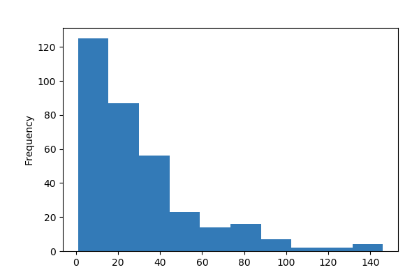

**Common Values**

| Value | Count | Frequency (%) |  |
| --- | --- | --- | --- |
| 14.0 | 13 | 1.7% |  |
| 4.0 | 11 | 1.5% |  |
| 10.0 | 11 | 1.5% |  |
| 9.0 | 9 | 1.2% |  |
| 23.0 | 9 | 1.2% |  |
| 22.0 | 9 | 1.2% |  |
| 1.0 | 9 | 1.2% |  |
| 15.0 | 9 | 1.2% |  |
| 7.0 | 9 | 1.2% |  |
| 13.0 | 9 | 1.2% |  |
| Other values (78) | 238 | 31.9% |  |
| (Missing) | 410 | 55.0% |  |

**Extreme Values**

Minimum 5 values

| Value | Count | Frequency (%) |  |
| --- | --- | --- | --- |
| 1.0 | 9 | 1.2% |  |
| 2.0 | 7 | 0.9% |  |
| 3.0 | 5 | 0.7% |  |
| 4.0 | 11 | 1.5% |  |
| 5.0 | 6 | 0.8% |  |

Maximum 5 values

| Value | Count | Frequency (%) |  |
| --- | --- | --- | --- |
| 130.0 | 1 | 0.1% |  |
| 138.0 | 1 | 0.1% |  |
| 140.0 | 1 | 0.1% |  |
| 144.0 | 1 | 0.1% |  |
| 146.0 | 1 | 0.1% |  |

win_by_wickets  
Numeric

| Distinct count | 11 |
| --- | --- |
| Unique (%) | 1.5% |
| Missing (%) | 46.6% |
| Missing (n) | 348 |
| Infinite (%) | 0.0% |
| Infinite (n) | 0 |

| Mean | 6.2513 |
| --- | --- |
| Minimum | 1 |
| Maximum | 10 |
| Zeros (%) | 0.0% |

Toggle details

**Statistics**

Quantile statistics

| Minimum | 1 |
| --- | --- |
| 5-th percentile | 3 |
| Q1 | 5 |
| Median | 6 |
| Q3 | 8 |
| 95-th percentile | 9 |
| Maximum | 10 |
| Range | 9 |
| Interquartile range | 3 |

Descriptive statistics

| Standard deviation | 1.8213 |
| --- | --- |
| Coef of variation | 0.29135 |
| Kurtosis | -0.26113 |
| Mean | 6.2513 |
| MAD | 1.4763 |
| Skewness | -0.16047 |
| Sum | 2488 |
| Variance | 3.3171 |
| Memory size | 6.0 KiB |

**Histogram**

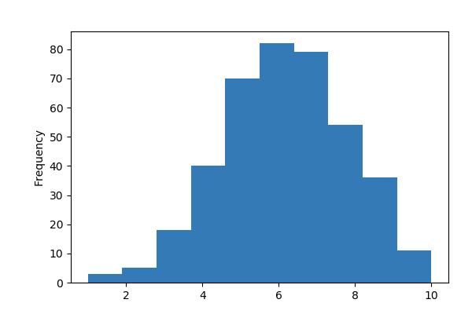

**Common Values**

| Value | Count | Frequency (%) |  |
| --- | --- | --- | --- |
| 6.0 | 82 | 11.0% |  |
| 7.0 | 79 | 10.6% |  |
| 5.0 | 70 | 9.4% |  |
| 8.0 | 54 | 7.2% |  |
| 4.0 | 40 | 5.4% |  |
| 9.0 | 36 | 4.8% |  |
| 3.0 | 18 | 2.4% |  |
| 10.0 | 11 | 1.5% |  |
| 2.0 | 5 | 0.7% |  |
| 1.0 | 3 | 0.4% |  |
| (Missing) | 348 | 46.6% |  |

**Extreme Values**

Minimum 5 values

| Value | Count | Frequency (%) |  |
| --- | --- | --- | --- |
| 1.0 | 3 | 0.4% |  |
| 2.0 | 5 | 0.7% |  |
| 3.0 | 18 | 2.4% |  |
| 4.0 | 40 | 5.4% |  |
| 5.0 | 70 | 9.4% |  |

Maximum 5 values

| Value | Count | Frequency (%) |  |
| --- | --- | --- | --- |
| 6.0 | 82 | 11.0% |  |
| 7.0 | 79 | 10.6% |  |
| 8.0 | 54 | 7.2% |  |
| 9.0 | 36 | 4.8% |  |
| 10.0 | 11 | 1.5% |  |

result  
Categorical

| Distinct count | 3 |
| --- | --- |
| Unique (%) | 0.4% |
| Missing (%) | 98.4% |
| Missing (n) | 734 |

| tie | 8 |
| --- | --- |
| no result | 4 |
| (Missing) | 734 |

Toggle details

| Value | Count | Frequency (%) |  |
| --- | --- | --- | --- |
| tie | 8 | 1.1% |  |
| no result | 4 | 0.5% |  |
| (Missing) | 734 | 98.4% |  |

overs  
Constant

*This variable is constant and should be ignored for analysis*

| Constant value | 20 |
| --- | --- |

player_of_match  
Categorical

| Distinct count | 224 |
| --- | --- |
| Unique (%) | 30.0% |
| Missing (%) | 0.5% |
| Missing (n) | 4 |

| CH Gayle | 21 |
| --- | --- |
| AB de Villiers | 20 |
| RG Sharma | 17 |
| Other values (220) | 684 |

Toggle details

| Value | Count | Frequency (%) |  |
| --- | --- | --- | --- |
| CH Gayle | 21 | 2.8% |  |
| AB de Villiers | 20 | 2.7% |  |
| RG Sharma | 17 | 2.3% |  |
| DA Warner | 17 | 2.3% |  |
| MS Dhoni | 17 | 2.3% |  |
| YK Pathan | 16 | 2.1% |  |
| SR Watson | 15 | 2.0% |  |
| SK Raina | 14 | 1.9% |  |
| G Gambhir | 13 | 1.7% |  |
| V Kohli | 12 | 1.6% |  |
| Other values (213) | 580 | 77.7% |  |

venue  
Categorical

| Distinct count | 36 |
| --- | --- |
| Unique (%) | 4.8% |
| Missing (%) | 0.0% |
| Missing (n) | 0 |

| Eden Gardens | 77 |
| --- | --- |
| Feroz Shah Kotla | 73 |
| Wankhede Stadium | 71 |
| Other values (33) | 525 |

Toggle details

| Value | Count | Frequency (%) |  |
| --- | --- | --- | --- |
| Eden Gardens | 77 | 10.3% |  |
| Feroz Shah Kotla | 73 | 9.8% |  |
| Wankhede Stadium | 71 | 9.5% |  |
| M Chinnaswamy Stadium | 66 | 8.8% |  |
| Rajiv Gandhi International Stadium, Uppal | 63 | 8.4% |  |
| MA Chidambaram Stadium, Chepauk | 56 | 7.5% |  |
| Sawai Mansingh Stadium | 47 | 6.3% |  |
| Punjab Cricket Association Stadium, Mohali | 35 | 4.7% |  |
| Maharashtra Cricket Association Stadium | 21 | 2.8% |  |
| Punjab Cricket Association IS Bindra Stadium, Mohali | 19 | 2.5% |  |
| Other values (26) | 218 | 29.2% |  |

umpire1  
Categorical

| Distinct count | 50 |
| --- | --- |
| Unique (%) | 6.7% |
| Missing (%) | 0.1% |
| Missing (n) | 1 |

| HDPK Dharmasena | 78 |
| --- | --- |
| Asad Rauf | 51 |
| AK Chaudhary | 47 |
| Other values (46) | 569 |

Toggle details

| Value | Count | Frequency (%) |  |
| --- | --- | --- | --- |
| HDPK Dharmasena | 78 | 10.5% |  |
| Asad Rauf | 51 | 6.8% |  |
| AK Chaudhary | 47 | 6.3% |  |
| M Erasmus | 40 | 5.4% |  |
| Aleem Dar | 38 | 5.1% |  |
| BF Bowden | 37 | 5.0% |  |
| S Ravi | 36 | 4.8% |  |
| BR Doctrove | 34 | 4.6% |  |
| AY Dandekar | 24 | 3.2% |  |
| KN Ananthapadmanabhan | 23 | 3.1% |  |
| Other values (39) | 337 | 45.2% |  |

umpire2  
Categorical

| Distinct count | 49 |
| --- | --- |
| Unique (%) | 6.6% |
| Missing (%) | 0.1% |
| Missing (n) | 1 |

| S Ravi | 68 |
| --- | --- |
| C Shamshuddin | 56 |
| SJA Taufel | 54 |
| Other values (45) | 567 |

Toggle details

| Value | Count | Frequency (%) |  |
| --- | --- | --- | --- |
| S Ravi | 68 | 9.1% |  |
| C Shamshuddin | 56 | 7.5% |  |
| SJA Taufel | 54 | 7.2% |  |
| CK Nandan | 48 | 6.4% |  |
| RJ Tucker | 41 | 5.5% |  |
| BNJ Oxenford | 31 | 4.2% |  |
| RB Tiffin | 30 | 4.0% |  |
| VA Kulkarni | 29 | 3.9% |  |
| AK Chaudhary | 29 | 3.9% |  |
| Nitin Menon | 27 | 3.6% |  |
| Other values (38) | 332 | 44.5% |  |

umpire3  
Categorical

| Distinct count | 3 |
| --- | --- |
| Unique (%) | 0.4% |
| Missing (%) | 99.7% |
| Missing (n) | 744 |

| A Chaudary | 1 |
| --- | --- |
| S Ravi | 1 |
| (Missing) | 744 |

Toggle details

| Value | Count | Frequency (%) |  |
| --- | --- | --- | --- |
| A Chaudary | 1 | 0.1% |  |
| S Ravi | 1 | 0.1% |  |
| (Missing) | 744 | 99.7% |  |

first_bat_team  
Categorical

| Distinct count | 15 |
| --- | --- |
| Unique (%) | 2.0% |
| Missing (%) | 0.0% |
| Missing (n) | 0 |

| Mumbai Indians | 99 |
| --- | --- |
| Kings XI Punjab | 90 |
| Chennai Super Kings | 87 |
| Other values (12) | 470 |

Toggle details

| Value | Count | Frequency (%) |  |
| --- | --- | --- | --- |
| Mumbai Indians | 99 | 13.3% |  |
| Kings XI Punjab | 90 | 12.1% |  |
| Chennai Super Kings | 87 | 11.7% |  |
| Royal Challengers Bangalore | 85 | 11.4% |  |
| Kolkata Knight Riders | 82 | 11.0% |  |
| Delhi Daredevils | 72 | 9.7% |  |
| Rajasthan Royals | 66 | 8.8% |  |
| Sunrisers Hyderabad | 61 | 8.2% |  |
| Deccan Chargers | 43 | 5.8% |  |
| Pune Warriors | 20 | 2.7% |  |
| Other values (5) | 41 | 5.5% |  |

first_bowl_team  
Categorical

| Distinct count | 15 |
| --- | --- |
| Unique (%) | 2.0% |
| Missing (%) | 0.0% |
| Missing (n) | 0 |

| Royal Challengers Bangalore | 94 |
| --- | --- |
| Kolkata Knight Riders | 94 |
| Delhi Daredevils | 89 |
| Other values (12) | 469 |

Toggle details

| Value | Count | Frequency (%) |  |
| --- | --- | --- | --- |
| Royal Challengers Bangalore | 94 | 12.6% |  |
| Kolkata Knight Riders | 94 | 12.6% |  |
| Delhi Daredevils | 89 | 11.9% |  |
| Kings XI Punjab | 84 | 11.3% |  |
| Mumbai Indians | 84 | 11.3% |  |
| Rajasthan Royals | 80 | 10.7% |  |
| Chennai Super Kings | 73 | 9.8% |  |
| Sunrisers Hyderabad | 44 | 5.9% |  |
| Deccan Chargers | 32 | 4.3% |  |
| Pune Warriors | 26 | 3.5% |  |
| Other values (5) | 46 | 6.2% |  |

first_bat_score  
Numeric

| Distinct count | 148 |
| --- | --- |
| Unique (%) | 19.8% |
| Missing (%) | 0.0% |
| Missing (n) | 0 |
| Infinite (%) | 0.0% |
| Infinite (n) | 0 |

| Mean | 161.36 |
| --- | --- |
| Minimum | 56 |
| Maximum | 263 |
| Zeros (%) | 0.0% |

Toggle details

**Statistics**

Quantile statistics

| Minimum | 56 |
| --- | --- |
| 5-th percentile | 111 |
| Q1 | 142 |
| Median | 163 |
| Q3 | 182 |
| 95-th percentile | 209.75 |
| Maximum | 263 |
| Range | 207 |
| Interquartile range | 40 |

Descriptive statistics

| Standard deviation | 30.538 |
| --- | --- |
| Coef of variation | 0.18926 |
| Kurtosis | 0.49928 |
| Mean | 161.36 |
| MAD | 23.737 |
| Skewness | -0.20055 |
| Sum | 120370 |
| Variance | 932.56 |
| Memory size | 6.0 KiB |

**Histogram**

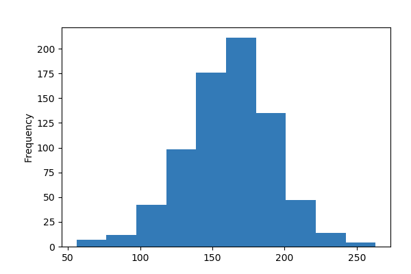

**Common Values**

| Value | Count | Frequency (%) |  |
| --- | --- | --- | --- |
| 187.0 | 16 | 2.1% |  |
| 165.0 | 15 | 2.0% |  |
| 168.0 | 14 | 1.9% |  |
| 163.0 | 14 | 1.9% |  |
| 178.0 | 14 | 1.9% |  |
| 160.0 | 14 | 1.9% |  |
| 164.0 | 13 | 1.7% |  |
| 161.0 | 12 | 1.6% |  |
| 183.0 | 12 | 1.6% |  |
| 158.0 | 12 | 1.6% |  |
| Other values (138) | 610 | 81.8% |  |

**Extreme Values**

Minimum 5 values

| Value | Count | Frequency (%) |  |
| --- | --- | --- | --- |
| 56.0 | 1 | 0.1% |  |
| 62.0 | 1 | 0.1% |  |
| 67.0 | 2 | 0.3% |  |
| 70.0 | 2 | 0.3% |  |
| 73.0 | 1 | 0.1% |  |

Maximum 5 values

| Value | Count | Frequency (%) |  |
| --- | --- | --- | --- |
| 240.0 | 1 | 0.1% |  |
| 245.0 | 1 | 0.1% |  |
| 246.0 | 1 | 0.1% |  |
| 248.0 | 1 | 0.1% |  |
| 263.0 | 1 | 0.1% |  |

second_bat_score  
Numeric

| Distinct count | 144 |
| --- | --- |
| Unique (%) | 19.3% |
| Missing (%) | 0.3% |
| Missing (n) | 2 |
| Infinite (%) | 0.0% |
| Infinite (n) | 0 |

| Mean | 147.84 |
| --- | --- |
| Minimum | 2 |
| Maximum | 223 |
| Zeros (%) | 0.0% |

Toggle details

**Statistics**

Quantile statistics

| Minimum | 2 |
| --- | --- |
| 5-th percentile | 92 |
| Q1 | 131 |
| Median | 150 |
| Q3 | 169 |
| 95-th percentile | 194 |
| Maximum | 223 |
| Range | 221 |
| Interquartile range | 38 |

Descriptive statistics

| Standard deviation | 31.153 |
| --- | --- |
| Coef of variation | 0.21072 |
| Kurtosis | 0.91159 |
| Mean | 147.84 |
| MAD | 24.118 |
| Skewness | -0.61263 |
| Sum | 109990 |
| Variance | 970.53 |
| Memory size | 6.0 KiB |

**Histogram**

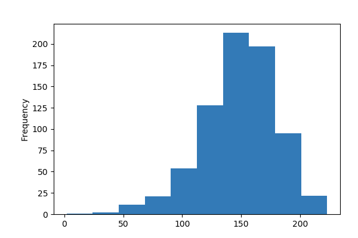

**Common Values**

| Value | Count | Frequency (%) |  |
| --- | --- | --- | --- |
| 164.0 | 14 | 1.9% |  |
| 146.0 | 14 | 1.9% |  |
| 161.0 | 14 | 1.9% |  |
| 162.0 | 14 | 1.9% |  |
| 142.0 | 13 | 1.7% |  |
| 160.0 | 13 | 1.7% |  |
| 150.0 | 13 | 1.7% |  |
| 159.0 | 13 | 1.7% |  |
| 137.0 | 12 | 1.6% |  |
| 158.0 | 11 | 1.5% |  |
| Other values (133) | 613 | 82.2% |  |

**Extreme Values**

Minimum 5 values

| Value | Count | Frequency (%) |  |
| --- | --- | --- | --- |
| 2.0 | 1 | 0.1% |  |
| 41.0 | 1 | 0.1% |  |
| 44.0 | 1 | 0.1% |  |
| 48.0 | 1 | 0.1% |  |
| 49.0 | 1 | 0.1% |  |

Maximum 5 values

| Value | Count | Frequency (%) |  |
| --- | --- | --- | --- |
| 208.0 | 2 | 0.3% |  |
| 211.0 | 1 | 0.1% |  |
| 214.0 | 2 | 0.3% |  |
| 217.0 | 1 | 0.1% |  |
| 223.0 | 2 | 0.3% |  |

Correlations

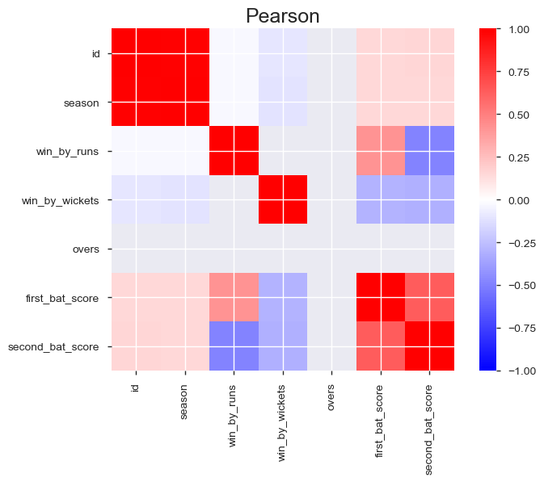

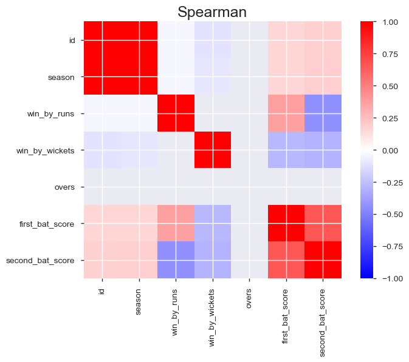

Sample

|  | id | season | city | date | team1 | team2 | toss_winner | toss_decision | winner | eliminator | dl_applied | win_by_runs | win_by_wickets | result | overs | player_of_match | venue | umpire1 | umpire2 | umpire3 | first_bat_team | first_bowl_team | first_bat_score | second_bat_score |
| --- | --- | --- | --- | --- | --- | --- | --- | --- | --- | --- | --- | --- | --- | --- | --- | --- | --- | --- | --- | --- | --- | --- | --- | --- |
| 0 | 419164 | 2010 | Mumbai | 2010-04-24 | Royal Challengers Bangalore | Deccan Chargers | Deccan Chargers | bat | Royal Challengers Bangalore | NaN | NaN | NaN | 9.0 | NaN | 20 | A Kumble | Dr DY Patil Sports Academy | RE Koertzen | SJA Taufel | NaN | Deccan Chargers | Royal Challengers Bangalore | 82.0 | 86.0 |
| 1 | 419131 | 2010 | Delhi | 2010-03-29 | Delhi Daredevils | Kolkata Knight Riders | Delhi Daredevils | bat | Delhi Daredevils | NaN | NaN | 40.0 | NaN | NaN | 20 | DA Warner | Feroz Shah Kotla | SS Hazare | SJA Taufel | NaN | Delhi Daredevils | Kolkata Knight Riders | 177.0 | 137.0 |
| 2 | 336021 | 2008 | Mumbai | 2008-05-16 | Mumbai Indians | Kolkata Knight Riders | Mumbai Indians | field | Mumbai Indians | NaN | NaN | NaN | 8.0 | NaN | 20 | SM Pollock | Wankhede Stadium | BR Doctrove | DJ Harper | NaN | Kolkata Knight Riders | Mumbai Indians | 67.0 | 68.0 |
| 3 | 980931 | 2016 | Pune | 2016-04-22 | Rising Pune Supergiants | Royal Challengers Bangalore | Rising Pune Supergiants | field | Royal Challengers Bangalore | NaN | NaN | 13.0 | NaN | NaN | 20 | AB de Villiers | Maharashtra Cricket Association Stadium | CB Gaffaney | VK Sharma | NaN | Royal Challengers Bangalore | Rising Pune Supergiants | 185.0 | 172.0 |
| 4 | 419163 | 2010 | Mumbai | 2010-04-22 | Chennai Super Kings | Deccan Chargers | Chennai Super Kings | bat | Chennai Super Kings | NaN | NaN | 38.0 | NaN | NaN | 20 | DE Bollinger | Dr DY Patil Sports Academy | BR Doctrove | RB Tiffin | NaN | Chennai Super Kings | Deccan Chargers | 142.0 | 104.0 |

```python
#Getting the pandas profiling report
pandas_profiling.ProfileReport(df)
```

```python
#Getting an htl file as output here
pandas_profiling.ProfileReport(df).to_file()
```

You can see the report in your directory in html format. It will give you a structured summarized view of statistics of every columns with interactive options to explore more.

# Steps Ahead

Try it yourself -

Create a Pandas Profile report for inninigs_data.csv in IPL Data.

Happy Learning